# Project 7

Yue Peng, Ludan Zhang, Jiachen Zhang, Kun Meng

Due October 26, 2016 at 5:00pm

# Project Goals:

The goal of this project is to get better aquainted with Dplyr and working with data.

Project 7 Markdown

# New York City Flights 13

```r
library(nycflights13)
library(dplyr)
flights
```

```
## # A tibble: 336,776 × 19
##     year month   day dep_time sched_dep_time dep_delay arr_time
##    <int> <int> <int>    <int>          <int>     <dbl>    <int>
## 1   2013     1     1      517            515         2      830
## 2   2013     1     1      533            529         4      850
## 3   2013     1     1      542            540         2      923
## 4   2013     1     1      544            545        -1     1004
## 5   2013     1     1      554            600        -6      812
## 6   2013     1     1      554            558        -4      740
## 7   2013     1     1      555            600        -5      913
## 8   2013     1     1      557            600        -3      709
## 9   2013     1     1      557            600        -3      838
## 10  2013     1     1      558            600        -2      753
## # ... with 336,766 more rows, and 12 more variables: sched_arr_time <int>,
## #   arr_delay <dbl>, carrier <chr>, flight <int>, tailnum <chr>,
## #   origin <chr>, dest <chr>, air_time <dbl>, distance <dbl>, hour <dbl>,
## #   minute <dbl>, time_hour <dttm>
```

# Basic Dyplyr

The deplyr package uses verbs to perform data manipulation. - `filter()` and `slice()` - `arrange()` - `select()` and `rename()` - `distinct()` - `mutate()` and `transmute()` - `sample_n()` and `sample_frac()`

## Filtering Rows

1. Filter all flights on your birthday.

```r
bir_month <- 8
bir_day <- 14
flights %>%
filter(month == bir_month, day == bir_day)
```

```
## # A tibble: 997 × 19
##     year month   day dep_time sched_dep_time dep_delay arr_time
##    <int> <int> <int>    <int>          <int>     <dbl>    <int>
## 1   2013     8    14        7           2359         8      344
## 2   2013     8    14       21           2359        22      358
## 3   2013     8    14       56           2359        57      439
## 4   2013     8    14      457            500        -3      640
## 5   2013     8    14      535            540        -5      840
## 6   2013     8    14      535            530         5      809
## 7   2013     8    14      542            545        -3     1008
## 8   2013     8    14      542            545        -3      821
## 9   2013     8    14      553            600        -7      703
## 10  2013     8    14      554            600        -6      648
## # ... with 987 more rows, and 12 more variables: sched_arr_time <int>,
## #   arr_delay <dbl>, carrier <chr>, flight <int>, tailnum <chr>,
## #   origin <chr>, dest <chr>, air_time <dbl>, distance <dbl>, hour <dbl>,
## #   minute <dbl>, time_hour <dttm>
```

2. Filter all flights in rows 567 - 589

```r
flights %>%
  slice(567:589)
```

```
## # A tibble: 23 × 19
##     year month   day dep_time sched_dep_time dep_delay arr_time
##    <int> <int> <int>    <int>          <int>     <dbl>    <int>
## 1   2013     1     1     1653           1700        -7     2005
## 2   2013     1     1     1654           1644        10     1752
## 3   2013     1     1     1654           1700        -6     2020
## 4   2013     1     1     1655           1621        34     1804
## 5   2013     1     1     1655           1700        -5     1953
## 6   2013     1     1     1655           1700        -5     2027
## 7   2013     1     1     1655           1655         0     2025
## 8   2013     1     1     1656           1700        -4     1941
## 9   2013     1     1     1657           1650         7     1921
## 10  2013     1     1     1657           1630        27     1948
## # ... with 13 more rows, and 12 more variables: sched_arr_time <int>,
## #   arr_delay <dbl>, carrier <chr>, flight <int>, tailnum <chr>,
## #   origin <chr>, dest <chr>, air_time <dbl>, distance <dbl>, hour <dbl>,
## #   minute <dbl>, time_hour <dttm>
```

## Arranging Rows

1. Use `arrange()` to order the data by `year, month and day`

```r
flights %>%
  arrange(year, month, day)
```

```
## # A tibble: 336,776 × 19
##     year month   day dep_time sched_dep_time dep_delay arr_time
##    <int> <int> <int>    <int>          <int>     <dbl>    <int>
## 1   2013     1     1      517            515         2      830
## 2   2013     1     1      533            529         4      850
## 3   2013     1     1      542            540         2      923
## 4   2013     1     1      544            545        -1     1004
## 5   2013     1     1      554            600        -6      812
## 6   2013     1     1      554            558        -4      740
## 7   2013     1     1      555            600        -5      913
## 8   2013     1     1      557            600        -3      709
## 9   2013     1     1      557            600        -3      838
## 10  2013     1     1      558            600        -2      753
## # ... with 336,766 more rows, and 12 more variables: sched_arr_time <int>,
## #   arr_delay <dbl>, carrier <chr>, flight <int>, tailnum <chr>,
## #   origin <chr>, dest <chr>, air_time <dbl>, distance <dbl>, hour <dbl>,
## #   minute <dbl>, time_hour <dttm>
```

2. Use `desc()` to arrange flights by arrival delay.

```r
flights %>%
  arrange(desc(arr_delay))
```

```
## # A tibble: 336,776 × 19
##     year month   day dep_time sched_dep_time dep_delay arr_time
##    <int> <int> <int>    <int>          <int>     <dbl>    <int>
## 1   2013     1     9      641            900      1301     1242
## 2   2013     6    15     1432           1935      1137     1607
## 3   2013     1    10     1121           1635      1126     1239
## 4   2013     9    20     1139           1845      1014     1457
## 5   2013     7    22      845           1600      1005     1044
## 6   2013     4    10     1100           1900       960     1342
## 7   2013     3    17     2321            810       911      135
## 8   2013     7    22     2257            759       898      121
## 9   2013    12     5      756           1700       896     1058
## 10  2013     5     3     1133           2055       878     1250
## # ... with 336,766 more rows, and 12 more variables: sched_arr_time <int>,
## #   arr_delay <dbl>, carrier <chr>, flight <int>, tailnum <chr>,
## #   origin <chr>, dest <chr>, air_time <dbl>, distance <dbl>, hour <dbl>,
## #   minute <dbl>, time_hour <dttm>
```

## Select

1. Select columns containing date information.

```r
flights %>%
  select(year, month, day, time_hour)
```

```
## # A tibble: 336,776 × 4
##     year month   day           time_hour
##    <int> <int> <int>              <dttm>
## 1   2013     1     1 2013-01-01 05:00:00
## 2   2013     1     1 2013-01-01 05:00:00
## 3   2013     1     1 2013-01-01 05:00:00
## 4   2013     1     1 2013-01-01 05:00:00
## 5   2013     1     1 2013-01-01 06:00:00
## 6   2013     1     1 2013-01-01 05:00:00
## 7   2013     1     1 2013-01-01 06:00:00
## 8   2013     1     1 2013-01-01 06:00:00
## 9   2013     1     1 2013-01-01 06:00:00
## 10  2013     1     1 2013-01-01 06:00:00
## # ... with 336,766 more rows
```

2. Select columns including only plane information.

```r
flights %>%
  select(carrier, flight, tailnum)
```

```
## # A tibble: 336,776 × 3
##    carrier flight tailnum
##      <chr>  <int>   <chr>
## 1       UA   1545  N14228
## 2       UA   1714  N24211
## 3       AA   1141  N619AA
## 4       B6    725  N804JB
## 5       DL    461  N668DN
## 6       UA   1696  N39463
## 7       B6    507  N516JB
## 8       EV   5708  N829AS
## 9       B6     79  N593JB
## 10      AA    301  N3ALAA
## # ... with 336,766 more rows
```

3. Rename `tailnum` to `tail_num`

```r
flights %>%
  select(tail_num = tailnum)
```

```
## # A tibble: 336,776 × 1
##    tail_num
##       <chr>
## 1    N14228
## 2    N24211
## 3    N619AA
## 4    N804JB
## 5    N668DN
## 6    N39463
## 7    N516JB
## 8    N829AS
## 9    N593JB
## 10   N3ALAA
## # ... with 336,766 more rows
```

```r
#rename(flights, tail_num = tailnum)
```

## Mutating Rows

1. Create a variable called `gain` which describes the difference between arrival delap and departure delay.

```r
flights %>%
  mutate(gain = arr_delay - dep_delay)
```

```
## # A tibble: 336,776 × 20
##     year month   day dep_time sched_dep_time dep_delay arr_time
##    <int> <int> <int>    <int>          <int>     <dbl>    <int>
## 1   2013     1     1      517            515         2      830
## 2   2013     1     1      533            529         4      850
## 3   2013     1     1      542            540         2      923
## 4   2013     1     1      544            545        -1     1004
## 5   2013     1     1      554            600        -6      812
## 6   2013     1     1      554            558        -4      740
## 7   2013     1     1      555            600        -5      913
## 8   2013     1     1      557            600        -3      709
## 9   2013     1     1      557            600        -3      838
## 10  2013     1     1      558            600        -2      753
## # ... with 336,766 more rows, and 13 more variables: sched_arr_time <int>,
## #   arr_delay <dbl>, carrier <chr>, flight <int>, tailnum <chr>,
## #   origin <chr>, dest <chr>, air_time <dbl>, distance <dbl>, hour <dbl>,
## #   minute <dbl>, time_hour <dttm>, gain <dbl>
```

2. Create a variable called speed which is distance over time in hours.

```r
flights %>%
  mutate(speed = distance / air_time * 60)
```

```
## # A tibble: 336,776 × 20
##     year month   day dep_time sched_dep_time dep_delay arr_time
##    <int> <int> <int>    <int>          <int>     <dbl>    <int>
## 1   2013     1     1      517            515         2      830
## 2   2013     1     1      533            529         4      850
## 3   2013     1     1      542            540         2      923
## 4   2013     1     1      544            545        -1     1004
## 5   2013     1     1      554            600        -6      812
## 6   2013     1     1      554            558        -4      740
## 7   2013     1     1      555            600        -5      913
## 8   2013     1     1      557            600        -3      709
## 9   2013     1     1      557            600        -3      838
## 10  2013     1     1      558            600        -2      753
## # ... with 336,766 more rows, and 13 more variables: sched_arr_time <int>,
## #   arr_delay <dbl>, carrier <chr>, flight <int>, tailnum <chr>,
## #   origin <chr>, dest <chr>, air_time <dbl>, distance <dbl>, hour <dbl>,
## #   minute <dbl>, time_hour <dttm>, speed <dbl>
```

## Summarise

1. Summarise the average delay for all flights.

```r
flights %>%
  summarise(delay = mean(dep_delay, na.rm = TRUE))
```

```
## # A tibble: 1 × 1
##      delay
##      <dbl>
## 1 12.63907
```

# Overall Questions

1. Split the complete dataset into individual planes and then summarise each plane by counting the number of flights (count = n()) and computing the average distance and arrival delay . Then plot this:

```r
delay <- flights %>%
  group_by(tailnum) %>%
  summarise(count = n(), dist = mean(distance, na.rm = TRUE), delay = mean(arr_delay, na.rm = TRUE))
```

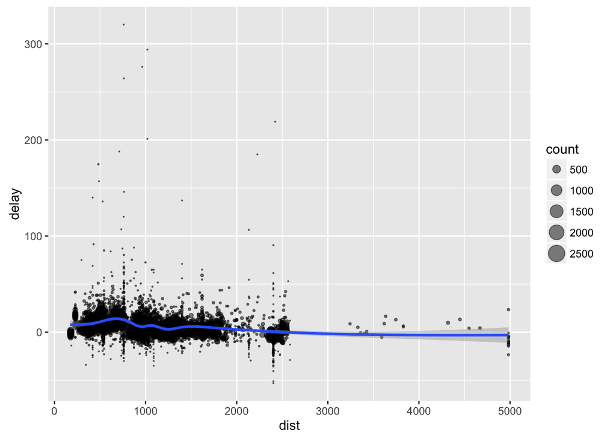

```r
library(ggplot2)
ggplot(delay, aes(dist, delay)) +
  geom_point(aes(size = count), alpha = 1/2) +
  geom_smooth() +
  scale_size_area()
```

2. Find the number of planes and the number of flights that go to each possible destination.

```r
flights %>%
  group_by(dest) %>%
  summarise(planes = n_distinct(tailnum), flights = n())
```

```
## # A tibble: 105 × 3
##     dest planes flights
##    <chr>  <int>   <int>
## 1    ABQ    108     254
## 2    ACK     58     265
## 3    ALB    172     439
## 4    ANC      6       8
## 5    ATL   1180   17215
## 6    AUS    993    2439
## 7    AVL    159     275
## 8    BDL    186     443
## 9    BGR     46     375
## 10   BHM     45     297
## # ... with 95 more rows
```

### More Difficult

In the videos we learned about piping our commands. The goal of piping is to help use with the flow of our analysis. The steps we take are: - Think about it. - Describe it. - Do it.

### Consider the function below:

```r
bas_r <- filter(
      summarise(
        select(
          group_by(flights, year, month, day),
          arr_delay, dep_delay
        ),
        arr = mean(arr_delay, na.rm = TRUE),
        dep = mean(dep_delay, na.rm = TRUE)
      ),
      arr > 30 | dep > 30
    )
```

1. What are some problems with this function?

```r
# If you want to understand this chunk of codes, you must read from inside to outside. It is not readable.
```

2. How easy is it to follow the logic of this?

```r
# Not easy to read in this way. We can rewrite it step by step, write down every step by natural thinking order.
```

3. Rewrite this using piping to make it more understandable.

```r
pip_r <- flights %>%
  group_by(year, month, day) %>%
  select(arr_delay, dep_delay) %>%
  summarise(arr = mean(arr_delay, na.rm = TRUE), dep = mean(dep_delay, na.rm = TRUE)) %>%
  filter(arr >30 | dep >30)
```

4. Use your function testing skills to verify they return the same results.

```r
all_equal(bas_r, pip_r)
```

```
## [1] TRUE
```

5. How would you write the above in terms of SQL?

```r
library(RMySQL)
library(DBI)
con <-dbConnect(MySQL(),
                user = "py0814",
                password = "seven=2+5",
                host = "yuedb.ccxrmxtuzhfi.us-east-1.rds.amazonaws.com",
                dbname = "Mydata")

query <- "SELECT year, month, day, AVG(arr_delay) AS arr, AVG(dep_delay) AS dep
          FROM flights
          GROUP BY year, month, day
          HAVING arr > 30 OR dep >30;"

dbGetQuery(con, query)
```

```
##    year month day      arr      dep
## 1  2013     1  16 34.24736 24.61287
## 2  2013     1  31 32.60285 28.65836
## 3  2013     2  11 36.29009 39.07360
## 4  2013     2  27 31.25249 37.76327
## 5  2013     3   8 85.86216 83.53692
## 6  2013     3  18 41.29189 30.11796
## 7  2013     4  10 38.41231 33.02368
## 8  2013     4  12 36.04814 34.83843
## 9  2013     4  18 36.02848 34.91536
## 10 2013     4  19 47.91170 46.12783
## 11 2013     4  22 37.81217 30.64255
## 12 2013     4  25 33.68125 23.33956
## 13 2013     5   8 39.60918 43.21778
## 14 2013     5  23 61.97090 51.14472
```

[output cut: 35 more lines]

### Consider the function below

```r
    hourly_delay <- filter(
              summarise(
                  group_by(
                      filter(
                        flights,
                        !is.na(dep_delay)
                        ),
                        month, day, hour
                        ),
                        delay=mean(dep_delay),
                        n=n()
                        ),
                        n>10
                        )
```

1. What are some problems with this function?

```r
# If you want to understand this chunk of codes, you must read from inside to outside. It is not readable from our natural logic.
```

2. How easy is it to follow the logic of this?

```r
# Not easy to read in this way. We can rewrite it step by step, write down every step by natural thinking order.
```

3. Rewrite this using piping to make it more understandable.

```r
hourly_delay2 <- flights %>%
  filter(!is.na(dep_delay)) %>%
  group_by(month, day, hour) %>%
  summarise(delay = mean(dep_delay), n = n()) %>%
  filter(n > 10)
```

4. Use your function testing skills to verify they return the same results.

```r
all_equal(hourly_delay, hourly_delay2)
```

```
## [1] TRUE
```

5. How would you write the above in terms of SQL?

```r
query2 <- "SELECT month, day, hour, AVG(dep_delay) AS delay, COUNT(*) AS n
           FROM flights
           WHERE dep_delay IS NOT NULL
           GROUP BY month, day, hour
           HAVING n > 10;"

dbGetQuery(con, query2)
```

```
##      month day hour        delay  n
## 1        1   1    6   2.15686275 51
## 2        1   1    7   3.51020408 49
## 3        1   1    8   0.44827586 58
## 4        1   1    9   5.33928571 56
## 5        1   1   10   0.33333333 39
## 6        1   1   11   3.18918919 37
## 7        1   1   12   5.75000000 56
## 8        1   1   13  20.37037037 54
## 9        1   1   14  17.25000000 48
## 10       1   1   15   7.77272727 66
## 11       1   1   16  16.31250000 64
## 12       1   1   17  28.47761194 67
## 13       1   1   18  26.47272727 55
## 14       1   1   19  14.73469388 49
```

[output cut: 5799 more lines]

## Consider how to join information from the other datasets in the package with the current information. Is there a way to tell if weather affected the departure time? Ask yourself other questions about this data and then answer them below.

[output not shown]